# NFL 2020 Week 11

# Cadet Individual Results

MA206 Individual Results

Week 11

Name

Weekly # Correct

Percent

Weeks Picked

Season Percent

Adj Season Percent

Season Trend

Week 1

Week 2

Week 3

Week 4

Week 5

Week 6

Week 7

Week 8

Week 9

Week 10

Week 11

Thomas Bizub

10

14

8

11

8

9

10

8

10

12

9

0.6923

11

0.6855

0.6855

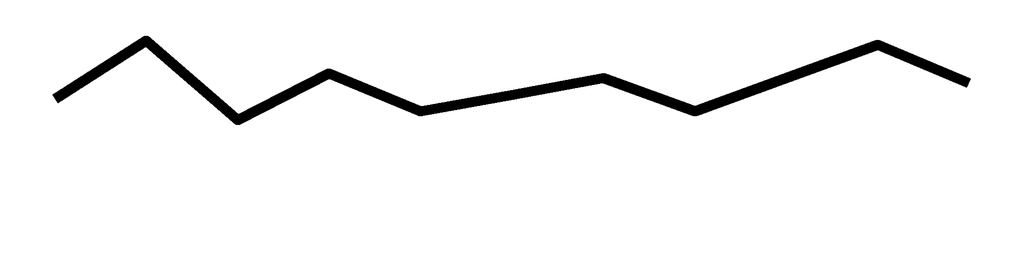

Caroline Swenson

8

12

11

13

7

8

10

NA

8

9

8

0.6154

10

0.6483

0.5894

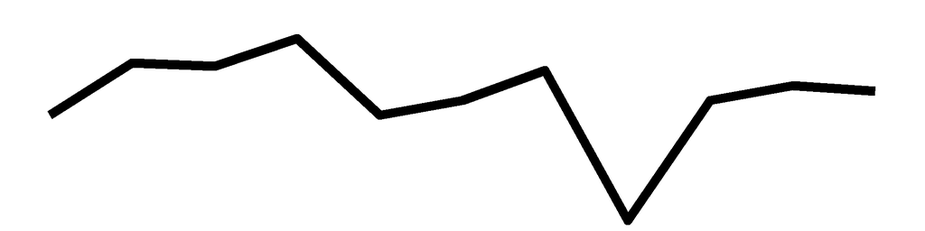

John White

10

11

10

8

12

9

11

6

9

9

8

0.6154

11

0.6478

0.6478

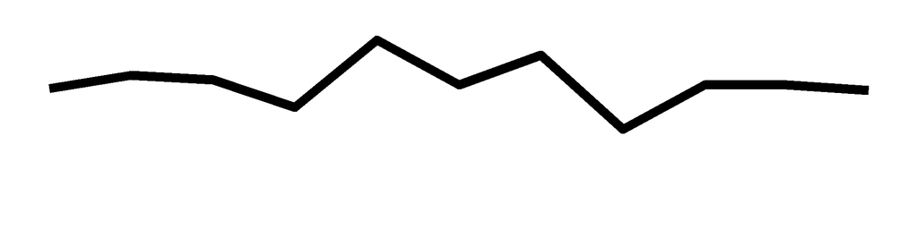

Jonathan Kemp

10

10

NA

NA

11

10

11

7

8

6

8

0.6154

9

0.6279

0.5137

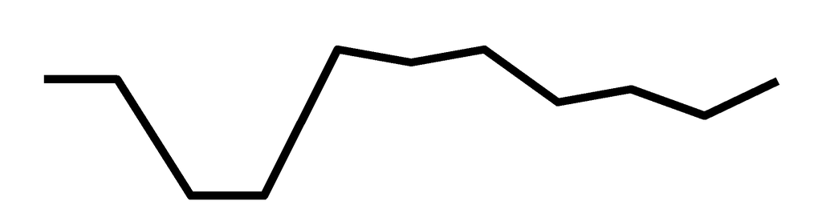

Sydney Shannon

10

9

8

9

8

7

9

5

8

10

8

0.6154

11

0.5723

0.5723

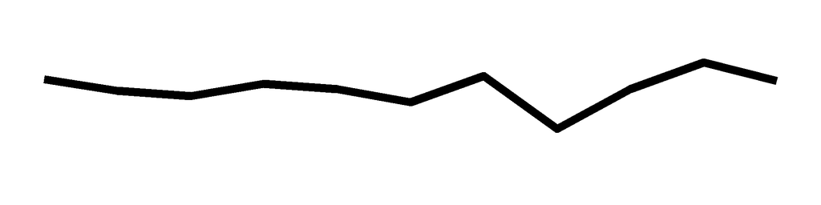

Laurence Dowd

10

10

10

9

10

NA

12

NA

10

8

7

0.5385

9

0.6565

0.5371

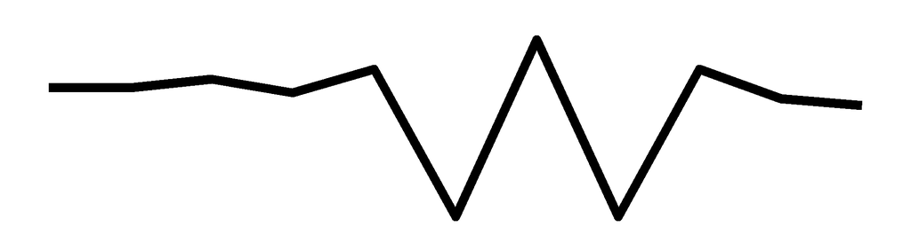

Paige Lennon

NA

NA

NA

11

10

8

11

8

6

8

6

0.4615

8

0.6071

0.4415

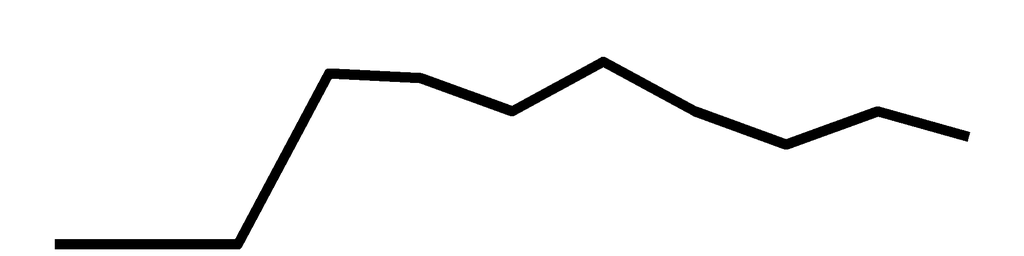

Victor Olawale-Apanpa

8

NA

10

NA

10

NA

10

7

7

9

6

0.4615

8

0.5877

0.4274

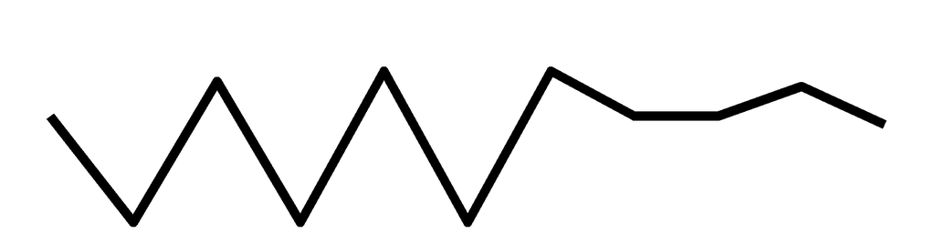

Gabriela Peralta

11

8

9

NA

8

8

10

6

NA

8

6

0.4615

9

0.5692

0.4657

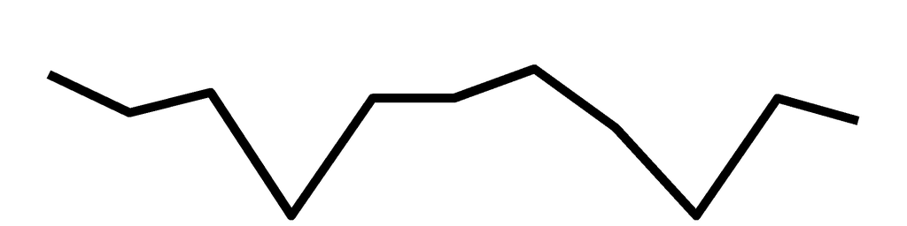

Christopher Erb

9

9

7

11

9

11

8

11

10

9

5

0.3846

11

0.6226

0.6226

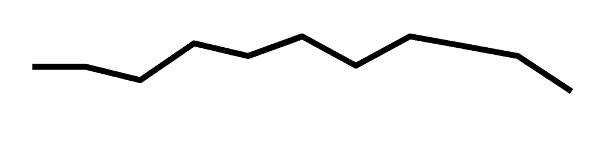

Sidney Cash

10

10

NA

10

NA

8

8

7

11

8

5

0.3846

9

0.5923

0.4846

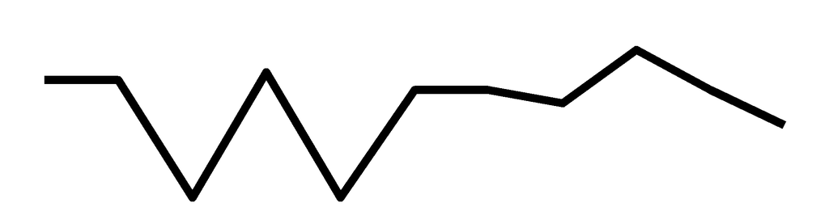

Ryan Jackovic

11

10

NA

7

7

8

8

7

NA

4

5

0.3846

9

0.5154

0.4217

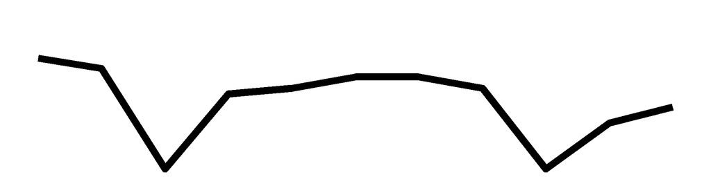

Kieran Place

12

11

8

NA

10

10

9

NA

NA

NA

NA

0.0000

6

0.6742

0.3677

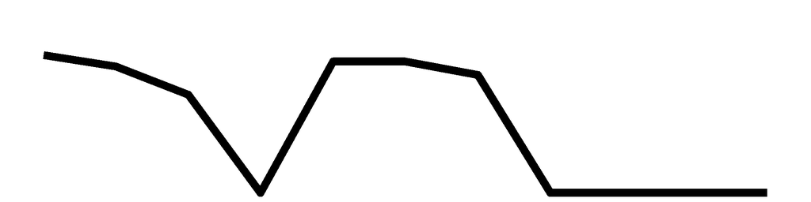

Luca Testa

NA

NA

10

NA

NA

NA

NA

NA

NA

NA

NA

0.0000

1

0.6667

0.0606

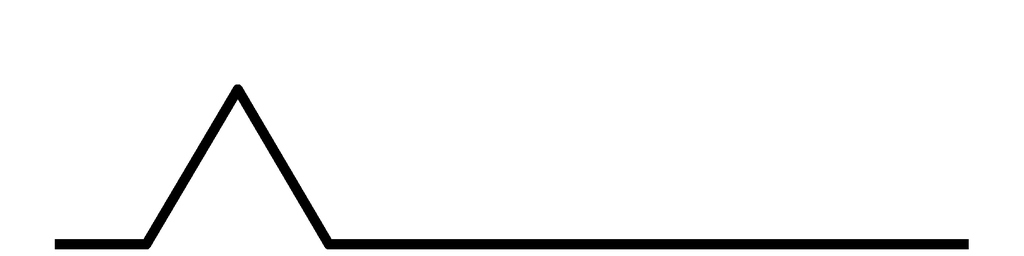

Zakai Bufkin

8

11

7

9

8

10

9

7

9

9

NA

0.0000

10

0.5959

0.5417

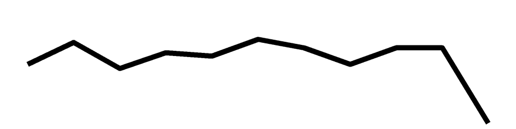

Cameron Patterson

11

9

8

NA

NA

NA

NA

NA

NA

NA

NA

0.0000

3

0.5957

0.1625

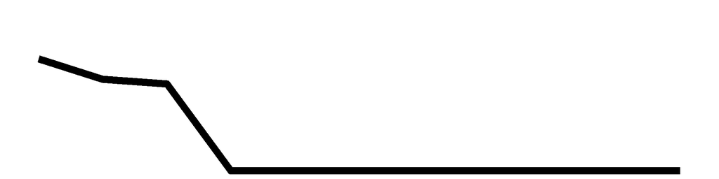

Joshua Loyd

11

9

8

NA

6

9

NA

6

10

8

NA

0.0000

8

0.5726

0.4164

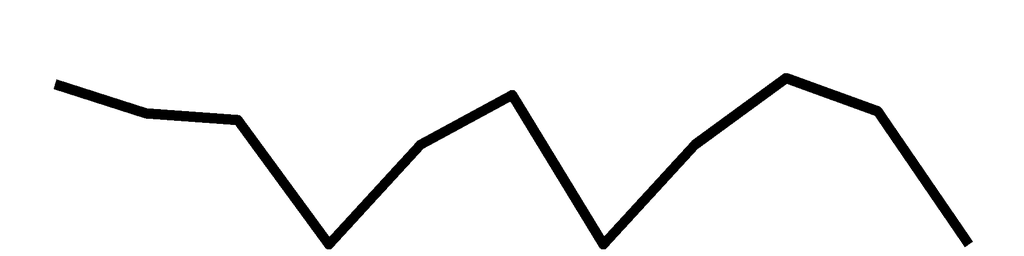

Joshua Gilliard

9

8

9

10

10

7

10

7

5

8

NA

0.0000

10

0.5685

0.5168

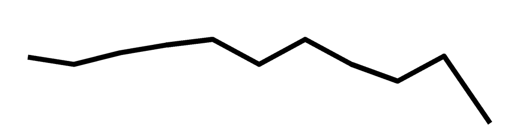

Amadou Bah

9

NA

NA

NA

NA

NA

NA

NA

NA

NA

NA

0.0000

1

0.5625

0.0511

Margaret Williams

9

NA

NA

NA

NA

NA

NA

NA

NA

NA

NA

0.0000

1

0.5625

0.0511

Logan Kauina

9

NA

NA

NA

NA

NA

NA

NA

NA

NA

NA

0.0000

1

0.5625

0.0511

Caleb John

NA

9

NA

NA

NA

NA

NA

NA

NA

NA

NA

0.0000

1

0.5625

0.0511

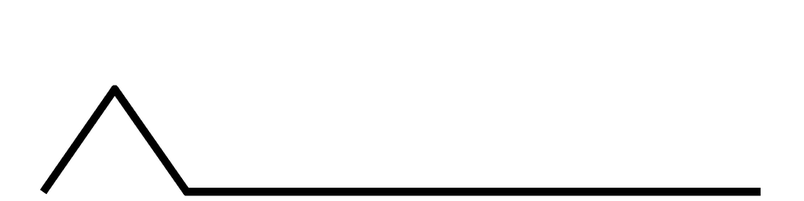

Jay Hajost

11

7

10

NA

6

NA

NA

7

9

NA

NA

0.0000

6

0.5618

0.3064

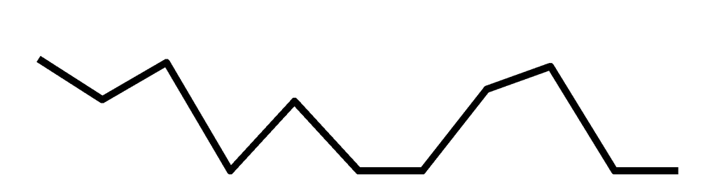

August Rannow

9

NA

NA

NA

7

NA

NA

NA

NA

NA

NA

0.0000

2

0.5333

0.0970

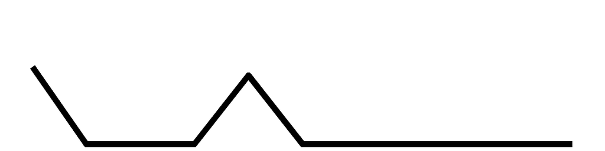

Peter Digenan

9

6

8

10

7

NA

NA

NA

NA

NA

NA

0.0000

5

0.5263

0.2392

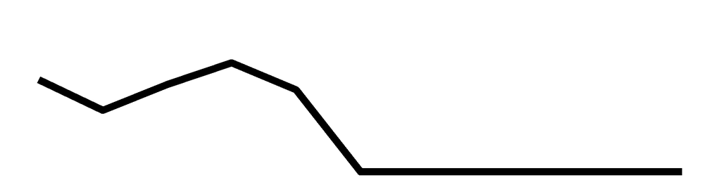

Caleb Doyle

9

NA

NA

NA

NA

NA

NA

6

NA

NA

NA

0.0000

2

0.5000

0.0909

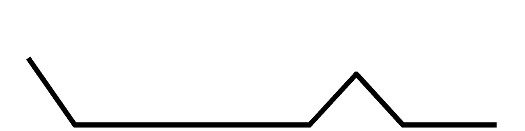

Sydney Johnson

NA

NA

NA

NA

NA

NA

NA

6

NA

NA

NA

0.0000

1

0.4286

0.0390

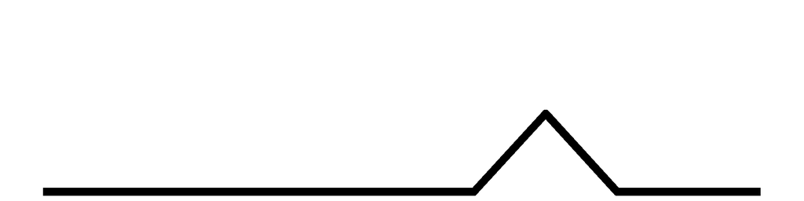

Congrats Thomas Bizub for having the best cadet picks this week, with a correct percentage of 0.6923

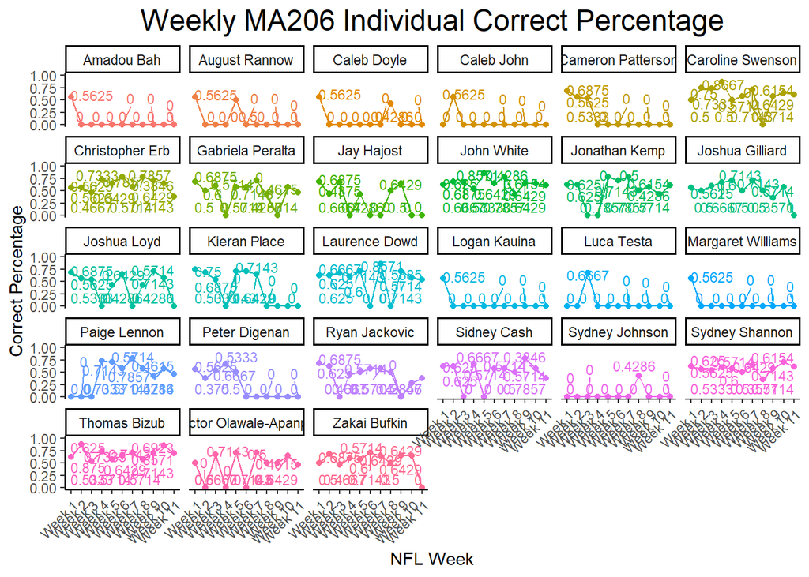

## Combined cadet and instructor prediction

This Week's Combined Cadet and Instructor Predictions

Week 11

| Game | Prediction | Winner | Correct | Correct Votes | Correct Percent |
| --- | --- | --- | --- | --- | --- |
| 1 | Seattle Seahawks | Seattle Seahawks | Yes | 19 | 0.6333 |
| 2 | New England Patriots | Houston Texans | No | 3 | 0.1000 |
| 3 | Detroit Lions | Carolina Panthers | No | 7 | 0.2333 |
| 4 | Cleveland Browns | Cleveland Browns | Yes | 29 | 0.9667 |
| 5 | Pittsburgh Steelers | Pittsburgh Steelers | Yes | 29 | 0.9667 |
| 6 | Baltimore Ravens | Tennessee Titans | No | 13 | 0.4333 |
| 7 | Cincinnati Bengals | Washington Football Team | No | 12 | 0.4000 |
| 8 | New Orleans Saints | New Orleans Saints | Yes | 23 | 0.7667 |
| 9 | Los Angeles Chargers | Los Angeles Chargers | Yes | 28 | 0.9333 |
| 10 | Miami Dolphins | Denver Broncos | No | 0 | 0.0000 |
| 11 | Minnesota Vikings | Dallas Cowboys | No | 1 | 0.0333 |
| 12 | Green Bay Packers | Indianapolis Colts | No | 12 | 0.4000 |
| 13 | Kansas City Chiefs | Kansas City Chiefs | Yes | 29 | 0.9667 |
| 14 | Tampa Bay Buccaneers | Los Angeles Rams | No | 4 | 0.1333 |

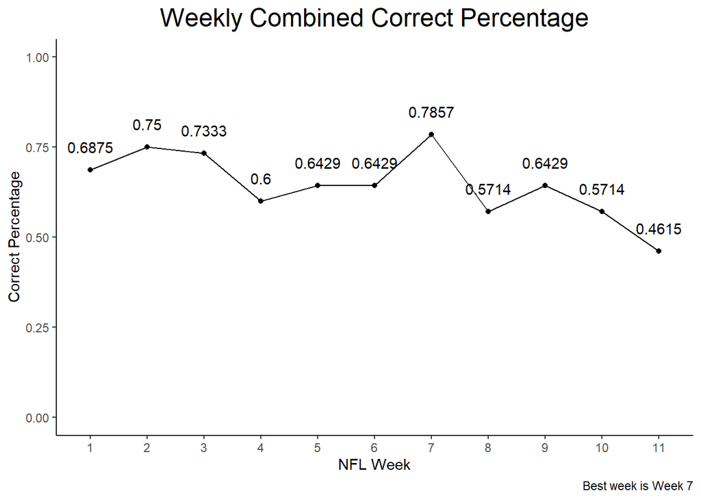

Our combined win percentage for the week is 0.4615

Our season combined win percentage so far is 0.6478

30 total predictions this week

This Week's Matched Cadet and Instructor Predictions

Week 11

| Game | Prediction | Correct |
| --- | --- | --- |
| 1 | Seattle Seahawks | Yes |
| 2 | New England Patriots | No |
| 3 | Detroit Lions | No |
| 4 | Cleveland Browns | Yes |
| 5 | Pittsburgh Steelers | Yes |
| 6 | -- | -- |
| 7 | -- | -- |
| 8 | New Orleans Saints | Yes |
| 9 | Los Angeles Chargers | Yes |
| 10 | Miami Dolphins | No |
| 11 | Minnesota Vikings | No |
| 12 | Green Bay Packers | No |
| 13 | Kansas City Chiefs | Yes |
| 14 | Tampa Bay Buccaneers | No |

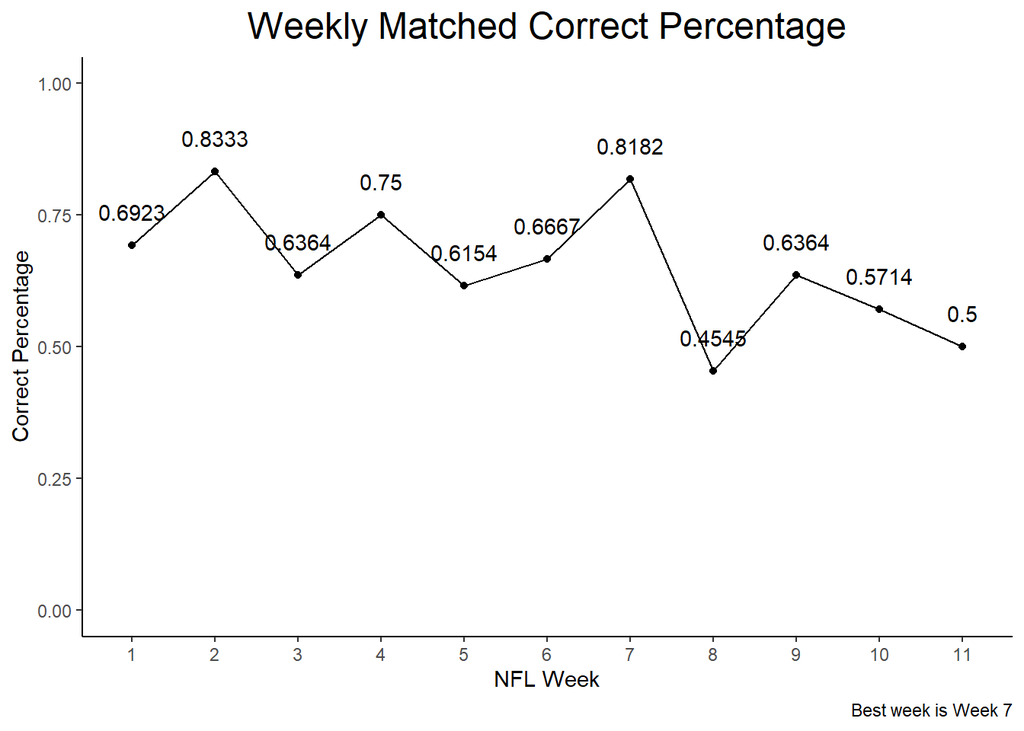

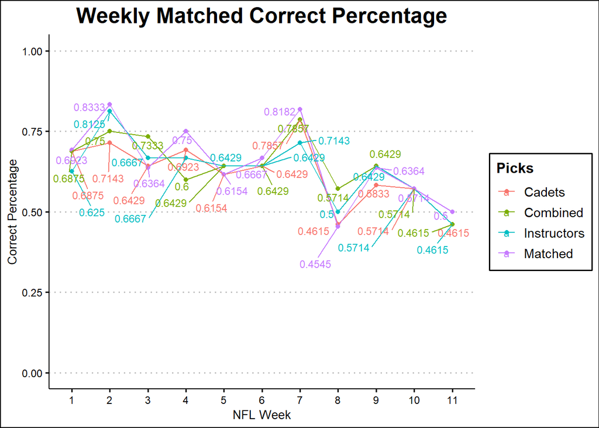